# Laboratorium 1

Ola Paluszynska

28 lutego 2017

# Uwagi do zajęć

#### Projekt

Etap 8 dotyczy ważenia obserwacji - nie będziemy tego omawiać na wykładzie (będziemy się zajmować danymi nieważonymi), więc trzeba poszukać w literaturze.

#### Zadanie domowe 1

Diagnostyka drugiego modelu z zajęć (wykonanie wszystkich testów wskazanych na githubie).

# Model liniowy

```r
setwd("~/UW/Modele_Liniowe_i_Mieszane")
# install.packages("PBImisc")
library(PBImisc)
library(ggplot2)
library(MASS)
library(lmtest)
data(heights)
data(genomes)
```

## Zależność pomiędzy wzrostem męża i żony

### Budowa modelu i weryfikacja liniowości

Budujemy model zależności między wzrostem męża i żony:

```r
model1 <- lm(Husband ~ Wife, data = heights)
summary(model1)
```

```
##
## Call:
## lm(formula = Husband ~ Wife, data = heights)
##
## Residuals:
##      Min       1Q   Median       3Q      Max
## -16.7438  -4.2838  -0.1615   4.2562  17.7500
##
## Coefficients:
##             Estimate Std. Error t value Pr(>|t|)
## (Intercept) 37.81005   11.93231   3.169  0.00207 **
## Wife         0.83292    0.07269  11.458  < 2e-16 ***
## ---
## Signif. codes:  0 '***' 0.001 '**' 0.01 '*' 0.05 '.' 0.1 ' ' 1
##
## Residual standard error: 6.468 on 94 degrees of freedom
## Multiple R-squared:  0.5828, Adjusted R-squared:  0.5783
## F-statistic: 131.3 on 1 and 94 DF,  p-value: < 2.2e-16
```

Przedstawimy graficznie zależność pomiędzy cechami:

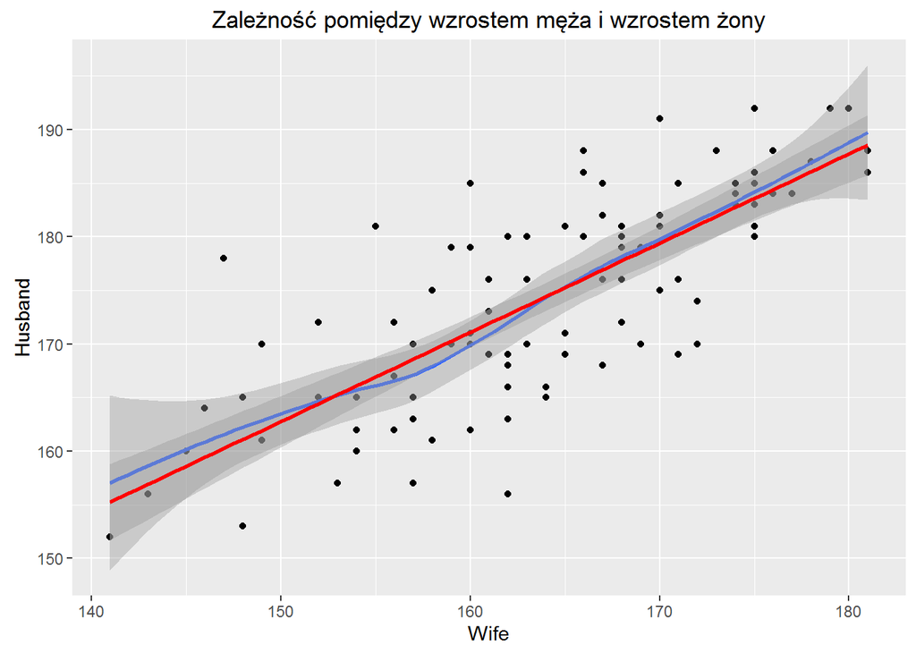

```r
ggplot(heights, aes(x = Wife, y = Husband)) + geom_point() + geom_smooth(formula = y ~ x, method = "loess") +
    geom_smooth(formula = y ~ x, method = "lm", color = "red") +
    ggtitle("Zależność pomiędzy wzrostem męża i wzrostem żony")
```

Sprawdzamy czy transformacja logarytmiczna nie poprawi liniowości modelu:

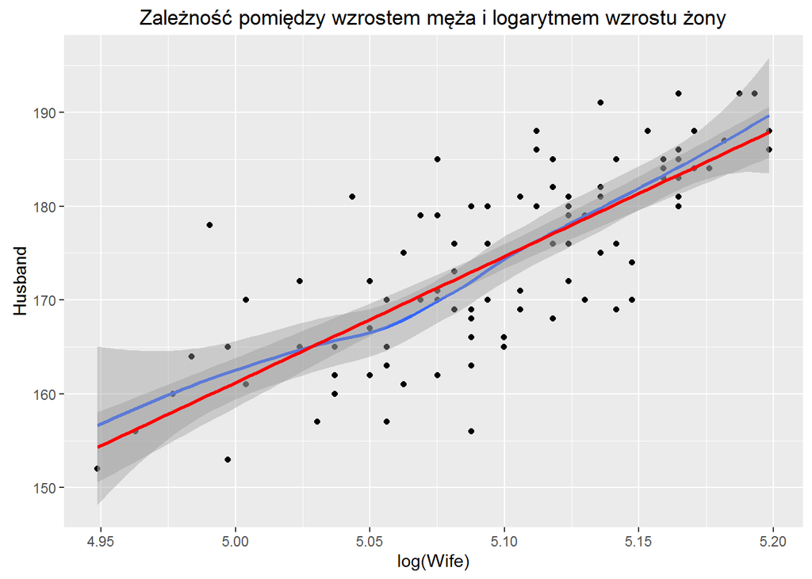

```r
ggplot(heights, aes(x = log(Wife), y = Husband)) + geom_point() + geom_smooth(formula = y ~ x, method = "loess")+
    geom_smooth(formula = y ~ x, method = "lm", color = "red") +
    ggtitle("Zależność pomiędzy wzrostem męża i logarytmem wzrostu żony")
```

Na pierwszym wykresie nie widać było problemu z liniowością (czerwona linia prosta mieściła się w przedziale ufności krzywej LOESS), zatem nic dziwnego, że transformacja logarytmiczna nie powoduje poprawy, jest więc zatem niepotrzebna.

## Zależność między długością genomu a współczynnikiem GC

### Budowa modelu i weryfikacja liniowości

Budujemy model zależności między długością genomu a współczynnikiem GC:

```r
model2.1 <- lm(GC ~ size, data = genomes)
summary(model2.1)
```

```
##
## Call:
## lm(formula = GC ~ size, data = genomes)
##
## Residuals:
##     Min      1Q  Median      3Q     Max
## -28.300  -8.217  -1.238   8.490  28.014
##
## Coefficients:
##             Estimate Std. Error t value Pr(>|t|)
## (Intercept)  32.6825     0.8235   39.69   <2e-16 ***
## size          4.2529     0.2041   20.84   <2e-16 ***
## ---
## Signif. codes:  0 '***' 0.001 '**' 0.01 '*' 0.05 '.' 0.1 ' ' 1
##
## Residual standard error: 10.38 on 722 degrees of freedom
## Multiple R-squared:  0.3755, Adjusted R-squared:  0.3746
## F-statistic: 434.1 on 1 and 722 DF,  p-value: < 2.2e-16
```

Przedstawimy graficznie zależność pomiędzy cechami:

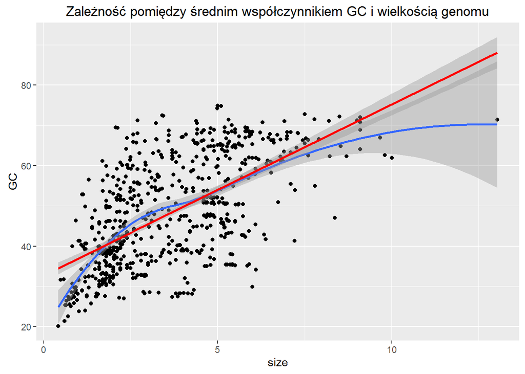

```r
ggplot(genomes, aes(x = size, y = GC)) + geom_point() + geom_smooth(formula = y ~ x, method = "loess") +
    geom_smooth(formula = y ~ x, method = "lm", color = "red") +
    ggtitle("Zależność pomiędzy średnim współczynnikiem GC i wielkością genomu")
```

Na wykresie widać, że czerwona prosta odpowiadająca modelowi liniowemu w kilku miejscach znacznie wykracza poza przedział ufności dla krzywej LOESS, więc założenie o liniowości badanej zależności wydaje się być niespełnione. Sprawdźmy, czy transformacja logarytmiczna poprawi tę sytuację:

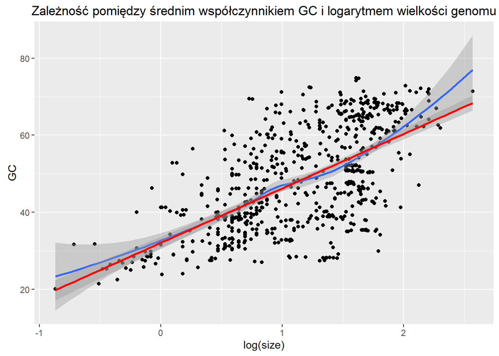

```r
model2.2 <- lm(GC ~ log(size), data = genomes)
ggplot(genomes, aes(x = log(size), y = GC)) + geom_point() + geom_smooth(formula = y ~ x, method = "loess") +
    geom_smooth(formula = y ~ x, method = "lm", color = "red") +
    ggtitle("Zależność pomiędzy średnim współczynnikiem GC i logarytmem wielkości genomu")
```

Widać, że po transformacji logarytmicznej krzywa LOESS jest niemalże prostą, a prosta regresji leży prawie całkowicie w obrębie przedziału ufności dla LOESS.

### Wykresy diagnostyczne

#### Jednorodność wiariancji

Na poniższym wykresie widać, że rozproszenie danych jest znacznie niższe przy krańcach przedziału, co jest sprzeczne z założeniem jednorodności wariancji:

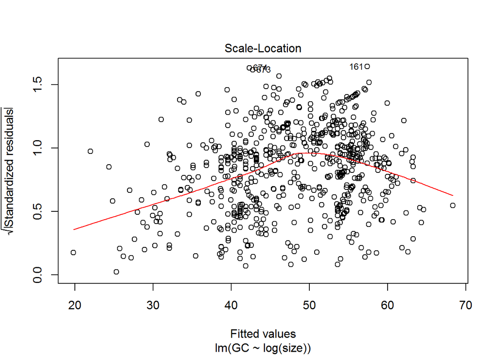

```r
plot(model2.2, which = 3)
```

Zauważmy, że rozkład zmiennej objaśnianej wyraźnie odbiega od rozkładu normalnego, co potwierdza również test Shapiro-Wilka, w którym odrzucamy hipotezę zerową o normalności rozkładu przy każdym sensownym poziomie istotności:

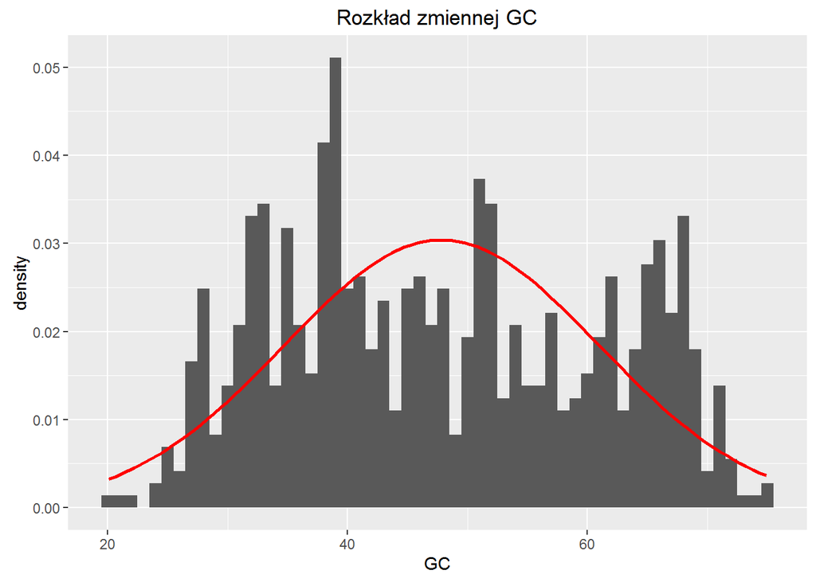

```r
ggplot(genomes, aes(x = GC)) + geom_histogram(aes(y=..density..), binwidth = 1) + stat_function(fun=dnorm, args=list(mean=mean(genomes$GC), sd=sd(genomes$GC)), color = "red", size = 1) + ggtitle("Rozkład zmiennej GC")
```

```r
shapiro.test(genomes$GC)
```

```
##
##  Shapiro-Wilk normality test
##
## data:  genomes$GC
## W = 0.95902, p-value = 2.444e-13
```

Rozważymy inne transformacje danych w celu poprawienia normalności zmiennej objaśnianej (szukamy najlepszego wykładnika dla transformacji Boxa-Coxa) mając nadzieję na rozwiązanie problemu niejednorodnej wariancji.

```r
bc <- boxcox(model2.1, plotit = FALSE)
(wykladnik <- bc$x[which.max(bc$y)]) # optymalny wykładnik
```

```
## [1] 0.5
```

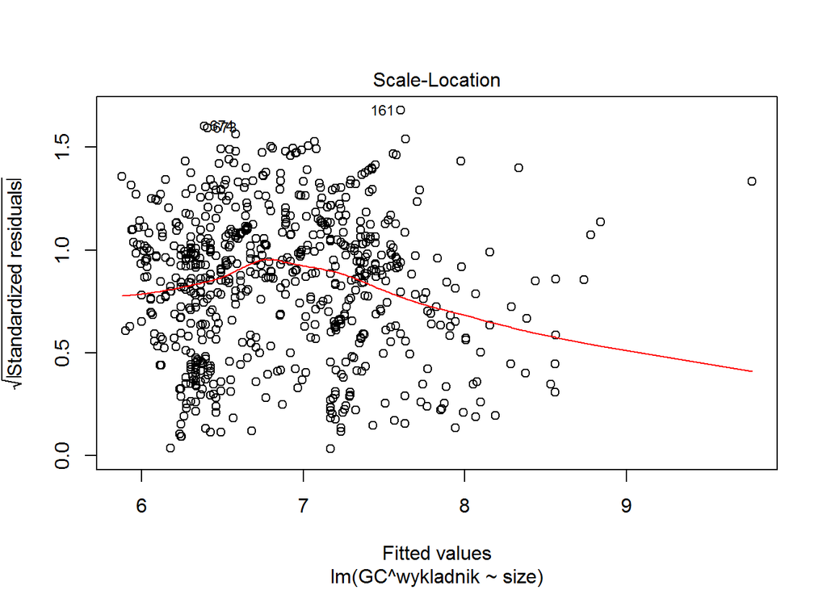

```r
model2.3 <- lm(GC^wykladnik ~ size, data = genomes)
plot(model2.3, which = 3)
```

Na powyższym wykresie widać, że przy zastosowaniu transformacji Boxa-Coxa z wykładnikiem 0.5 (maksymalizującą wiarygodność spośród rozpatrywanych przez nas wykładników) wariancja wciąż nie jest jednorodna (można twierdzić, że trochę się ustabilizowała, ale wciąż niewystarczająco).

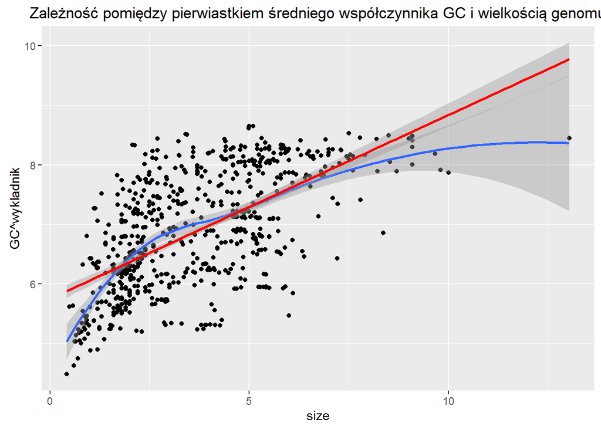

```r
ggplot(genomes, aes(x = size, y = GC^wykladnik)) + geom_point() + geom_smooth(formula = y ~ x, method = "loess") +
    geom_smooth(formula = y ~ x, method = "lm", color = "red") +
    ggtitle("Zależność pomiędzy pierwiastkiem średniego współczynnika GC i wielkością genomu")
```

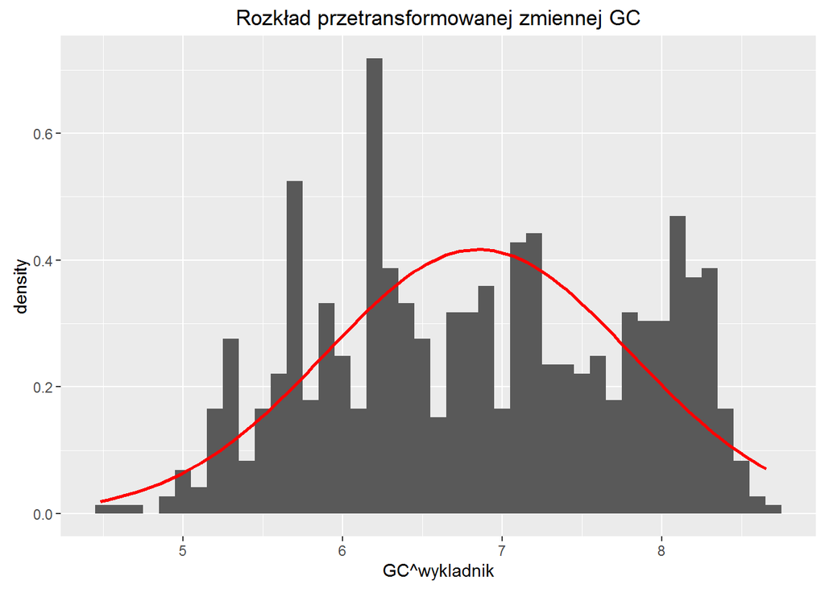

```r
ggplot(genomes, aes(x = GC^wykladnik)) + geom_histogram(aes(y=..density..), binwidth = 0.1) + stat_function(fun=dnorm, args=list(mean=mean(genomes$GC^wykladnik), sd=sd(genomes$GC^wykladnik)), color = "red", size = 1) + ggtitle("Rozkład przetransformowanej zmiennej GC")
```

```r
shapiro.test(genomes$GC^wykladnik)
```

```
##
##  Shapiro-Wilk normality test
##
## data:  genomes$GC^wykladnik
## W = 0.96517, p-value = 4.211e-12
```

Ponieważ wykonana transformacja nie pomogła, wracamy do modelu objaśniającego zmienną `GC` logarytmem wielkości genomu.

#### Analiza reszt

Teraz wyznaczymy reszty (standardowe oraz studentyzowane).

```r
reszty <- rbind(data.frame(reszty = rstandard(model2.2), typ = "Reszty standardowe"), data.frame(reszty = rstudent(model2.2), typ = "Reszty studentyzowane"))
```

Sprawdźmy, jak oba rodzaje reszt mają się do rozkładu normalnego. W tym celu przedstawimy ich rozkład za pomocą histogramu oraz wykresu QQ.

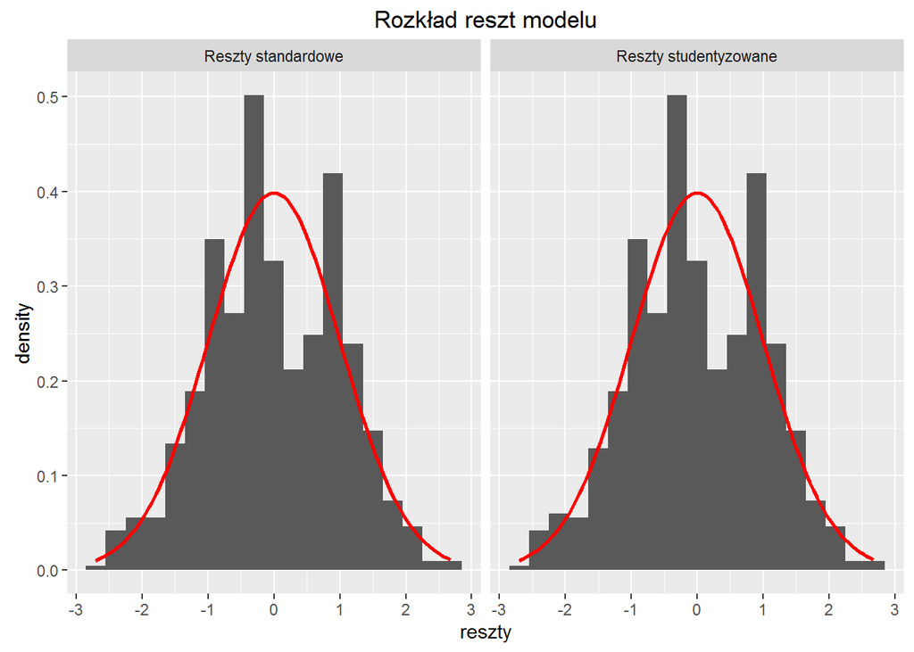

```r
ggplot(reszty, aes(x = reszty)) + geom_histogram(aes(y=..density..), binwidth = 0.3) + stat_function(fun=dnorm, args=list(mean=mean(reszty$reszty), sd=sd(reszty$reszty)), color = "red", size = 1) + ggtitle("Rozkład reszt modelu") + facet_grid(. ~ typ)
```

Na pierwszy rzut oka histogramy są identyczne. Nie jest to nic dziwnego biorąc pod uwagę, że mamy aż 724 obserwacji. Rozkład reszt wyraźnie odbiega od normalnego - sprawia wręcz wrażenie bimodalnego.

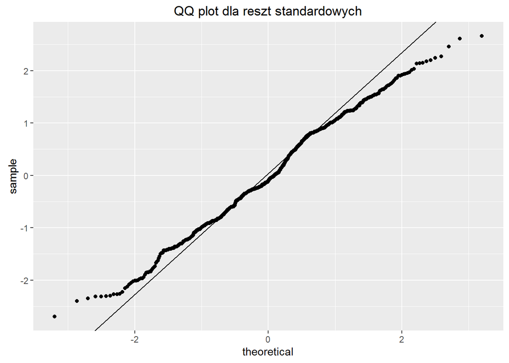

```r
qqplot.data <- function (vec, co) # argument: vector of numbers
{
  y <- quantile(vec[!is.na(vec)], c(0.25, 0.75))
  x <- qnorm(c(0.25, 0.75))
  slope <- diff(y)/diff(x)
  int <- y[1L] - slope * x[1L]
  d <- data.frame(resids = vec)
  ggplot(d, aes(sample = resids)) + stat_qq() + geom_abline(slope = slope, intercept = int) + ggtitle(paste0("QQ plot dla reszt ", co))
}
qqplot.data(reszty$reszty[reszty$typ == "Reszty standardowe"], co = "standardowych")
```

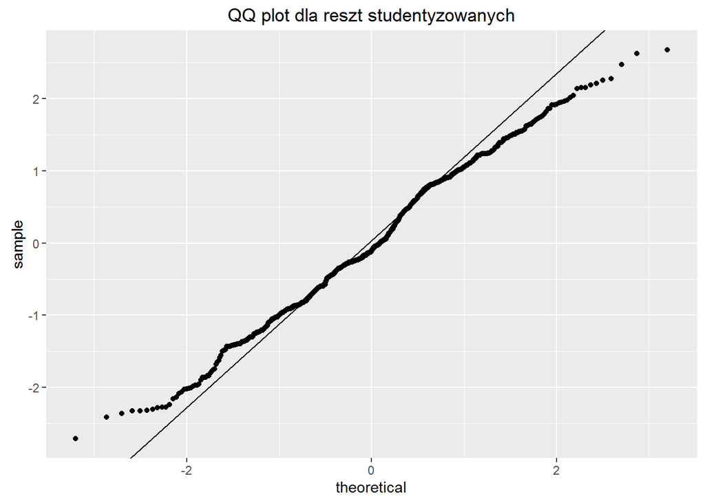

```r
qqplot.data(reszty$reszty[reszty$typ == "Reszty studentyzowane"], co = "studentyzowanych")
```

Oba powyższe wykresy QQ sugerują wyraźną rozbieżność rozkładu reszt z rozkładem normalnym, co nie jest dobrym znakiem.

#### Obserwacje wpływowe

Wyznaczamy odległość Cooka i przedstawiamy ją na wykresie:

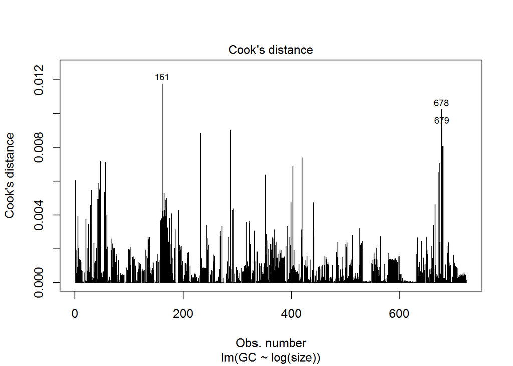

```r
odleglosc_cooka <- cooks.distance(model2.2)
plot(model2.2, which = 4)
```

Na powyższym wykresie widać trzy obserwacje o wyjątkowo wysokiej mierze Cooka, co sugeruje, że należy rozpatrzyć wyłączenie ich z próby. Warto jednak zaznaczyć, że dość duża liczba obserwacji (nieponumerowanych na wykresie) ma tę miarę niewiele niższą, więc ciężko jednoznacznie stwierdzić, które są odstające (nie ma wyraźnego odstawania).

### Testowanie

Wykonujemy testy diagnostyczne:

```r
bptest(model2.2)
```

```
##
##  studentized Breusch-Pagan test
##
## data:  model2.2
## BP = 17.207, df = 1, p-value = 3.352e-05
```

```r
testy <- paste0(c("gqtest", "hmctest", "dwtest", "harvtest", "raintest"), "(model2.2, order.by = ~size, data = genomes)")
for(i in 1:length(testy)){
    print(eval(parse(text=testy[i])))
}
```

```
##
##  Goldfeld-Quandt test
##
## data:  model2.2
## GQ = 1.4292, df1 = 360, df2 = 360, p-value = 0.000367
##
##
##  Harrison-McCabe test
##
## data:  model2.2
## HMC = 0.41099, p-value = 0.001
##
##
##  Durbin-Watson test
##
## data:  model2.2
## DW = 1.7805, p-value = 0.001377
## alternative hypothesis: true autocorrelation is greater than 0
##
##
##  Harvey-Collier test
##
## data:  model2.2
## HC = 1.1855, df = 721, p-value = 0.2362
##
##
##  Rainbow test
##
## data:  model2.2
## Rain = 0.65388, df1 = 362, df2 = 360, p-value = 1
```

```r
resettest(model2.2)
```

```
##
##  RESET test
##
## data:  model2.2
## RESET = 1.9135, df1 = 2, df2 = 720, p-value = 0.1483
```

```r
# Testy normalności reszt:
shapiro.test(reszty$reszty[reszty$typ == "Reszty standardowe"])
```

```
##
##  Shapiro-Wilk normality test
##
## data:  reszty$reszty[reszty$typ == "Reszty standardowe"]
## W = 0.99189, p-value = 0.0005388
```

```r
shapiro.test(reszty$reszty[reszty$typ == "Reszty studentyzowane"])
```

```
##
##  Shapiro-Wilk normality test
##
## data:  reszty$reszty[reszty$typ == "Reszty studentyzowane"]
## W = 0.99204, p-value = 0.0006288
```

Przyjmując poziom istotności równy 0.05 powyższe wyniki testów pozwalają nam stwierdzić, że:

- **Test Breuscha-Pagana:** odrzucamy hipotezę zerową o jednorodności wariancji reszt na rzecz hipotezy alternatywnej, że wariancja ta zależy od naszej zmiennej objaśniającej.
- **Test Godfelda-Quandta:** odrzucamy hipotezę zerową o równości wariancji w dwóch równolicznych grupach (jedna z obserwacjami o małej wielkości genomu, a druga o dużej, gdyż obserwacje uszeregowaliśmy wg wielkości genomu).
- **Test Harrisona-McCabe:** sprawdza tę samą hipotezę, co test test Goldfelda-Quandta - tutaj również odrzucamy hipotezę zerową o równości wariancji w dwóch grupach.
- **Test Durbina-Watsona:** odrzucamy hipotezę zerową na korzyść hipotezy alternatywnej, która mówi, że autokorelacja reszt jest większa od zera, co łamie założenie o niezależności reszt.
- **Test Breuscha-Godfrey’a:** odrzucamy hipotezę zerową o tym, że autokorelacja reszt do rzędu 4 włącznie jest zerowa, co oznacza, że występuje autokorelacja rzędu 1,2,3 lub 4 (nie jest to dziwne w obliczu wyniku testu Durbina-Watsona).

```r
bgtest(model2.2, order.by = ~size, order = 4, data = genomes)
```

```
##
##  Breusch-Godfrey test for serial correlation of order up to 4
##
## data:  model2.2
## LM test = 11.38, df = 4, p-value = 0.02261
```

### Podsumowanie

W celu poprawy tego modelu powinniśmy: przeanalizować dokładniej postać funkcyjną modelu (może bardziej wyrafinowana transformacja zmiennych byłaby odpowiednia?) oraz rozważyć dodanie dodatkowych zmiennyc objaśniających. Jeśli chodzi o niejednorodność wariancji, to moglibyśmy posłużyć się korektą błędów standardowych ją uwzględniającą.